# Analysing differential hydrogen deuterium exchange mass spectrometry data

Oliver M. Crook

16 February 2022

#### Abstract

This vignette describes how to analyse a mass-spectrometry based hydrogen deuterium exchange experiment, in particular we focus on empirical Bayes functional models and visualisations.

#### Package

hdxstats 1.0

# 1 An epitope mapping experiment

We now describe the analysis of an epitope mapping experiment. Here, the data analysis is more challenging, since only 1 replicate in each condition, apo and antibody, was performed. If we make some simplifying assumptions rigorous statistical analysis can still be performed.

The experiment was performed on HOIP-RBR, we loaded the data below from inside the package

```r
HOIPpath <- system.file("extdata", "N64184_1a2_state.csv", package = "hdxstats")
HOIP <- read.csv(HOIPpath)
```

```r
unique(HOIP$State)
```

```
##  [1] "apo"     "dAb13_1" "dAb13_2" "dAb25_1" "dAb25_2" "dAb27_1" "dAb27_2"
##  [8] "dAb2_1"  "dAb2_2"  "dAb6_1"  "dAb6_2"
```

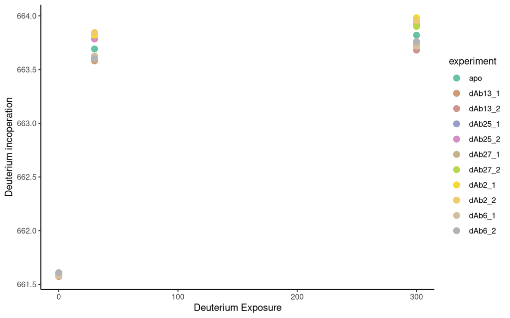

```r
HOIP$Exposure <- HOIP$Exposure * 60 #convert to seconds
filter(HOIP, Sequence == unique(HOIP$Sequence[1])) %>%
    ggplot(aes(x = Exposure,
               y = Center,
               color = factor(State, unique(HOIP$State)))) +
    theme_classic() + geom_point(size = 3) +
    scale_color_manual(values = colorRampPalette(brewer.pal(8, name = "Set2"))(11)) +
    labs(color = "experiment", x = "Deuterium Exposure", y = "Deuterium incoperation")
```

As before we need to convert data to an object of classes `QFeatures` for ease of analysis.

First, we put the data into a `DataFrame` object. Currently, its in long format so we switch to a wide format

```r
HOIP_wide <- pivot_wider(data.frame(HOIP),
                         values_from = Center,
                         names_from = c("Exposure", "State"),
                         id_cols = c("Sequence"))
```

Now remove all columns with only NAs

```r
HOIP_wide <- HOIP_wide[, colSums(is.na(HOIP_wide)) != nrow(HOIP_wide)]
```

The colanmes are not very informative, provide in the format X(time)rep(repliate)cond(condition)

```r
colnames(HOIP_wide)[-c(1)]
```

```
##  [1] "0_apo"       "30_apo"      "300_apo"     "0_dAb13_1"   "30_dAb13_1"
##  [6] "300_dAb13_1" "0_dAb13_2"   "30_dAb13_2"  "300_dAb13_2" "0_dAb25_1"
## [11] "30_dAb25_1"  "300_dAb25_1" "0_dAb25_2"   "30_dAb25_2"  "300_dAb25_2"
## [16] "0_dAb27_1"   "30_dAb27_1"  "300_dAb27_1" "0_dAb27_2"   "30_dAb27_2"
## [21] "300_dAb27_2" "0_dAb2_1"    "30_dAb2_1"   "300_dAb2_1"  "0_dAb2_2"
## [26] "30_dAb2_2"   "300_dAb2_2"  "0_dAb6_1"    "30_dAb6_1"   "300_dAb6_1"
## [31] "0_dAb6_2"    "30_dAb6_2"   "300_dAb6_2"
```

```r
new.colnames <- gsub("0_", "0rep1", paste0("X", colnames(HOIP_wide)[-c(1)]))
new.colnames <- gsub("rep1", "rep1cond", new.colnames)

# remove annoying % signs
new.colnames <- gsub("%", "", new.colnames)

# remove space (NULL could get confusing later and WT is clear)
new.colnames <- gsub(" .*", "", new.colnames)
```

Now, we can provide rownames and convert the data to a `QFeatures` object:

```r
qDF <- parseDeutData(object = DataFrame(HOIP_wide),
                     design = new.colnames,
                     quantcol = 2:34,
                     rownames = HOIP_wide$Sequence)
```

As before, we can produce a heatmap, we perform a simple normalisation for ease of visualisation:

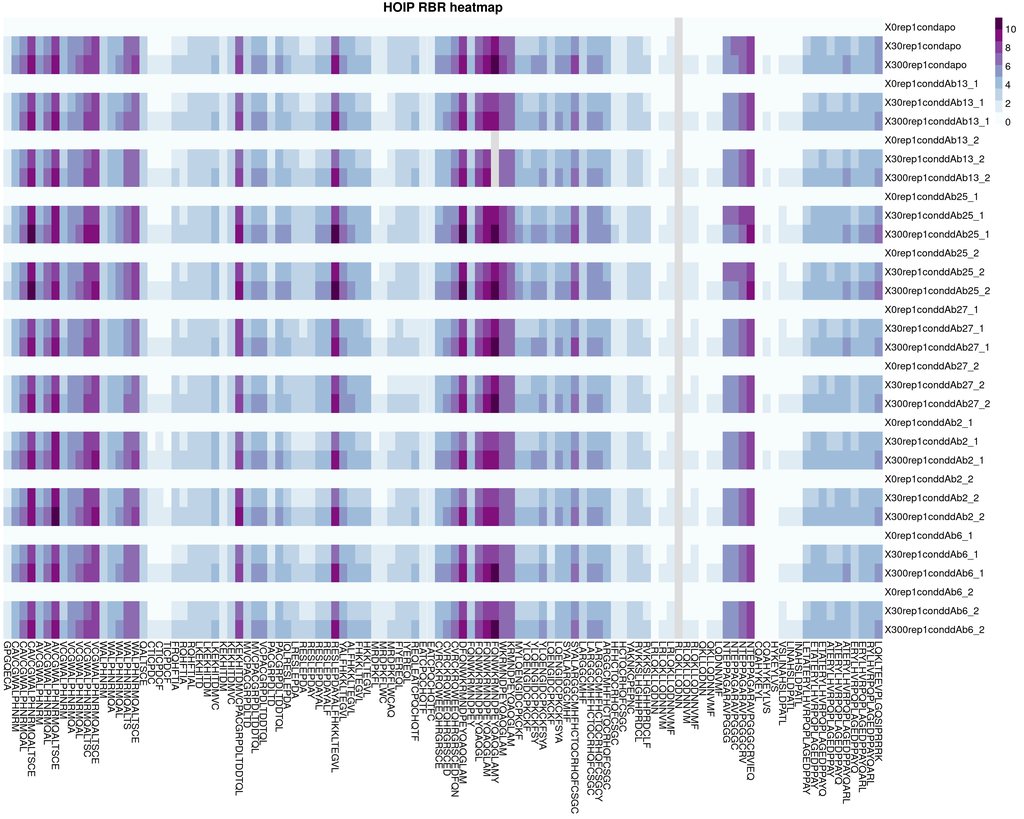

```r
mat <- assay(qDF)
mat <- apply(mat, 2, function(x) x - assay(qDF)[,1])

pheatmap(t(mat),
         cluster_rows = FALSE,
         cluster_cols = FALSE,
         color = brewer.pal(n = 9, name = "BuPu"),
         main = "HOIP RBR heatmap",
         fontsize = 14,
         legend_breaks = c(0, 2, 4, 6,8,10,12, max(assay(qDF))),
         legend_labels = c("0", "2", "4", "6", "8","10", "12", "Incorporation"))
```

Let us first perform a quick test:

```r
res <- differentialUptakeKinetics(object = qDF[,1:33],
                                  feature = rownames(qDF)[[1]][3],
                                  start = list(a = NULL, b = 0.01,  d = NULL),
                                  formula = value ~ a * (1 - exp(-b*(timepoint))) + d)
res@vis+ scale_color_manual(values = colorRampPalette(brewer.pal(8, name = "Set2"))(11))
```

[output not shown]

[figure not shown]

Whilst this analysis performs good fits for the functions, there are too many degrees of freedom to perform sound statistical analysis. Hence, we normalize to remove the degree of freedom for the intercept. For simplicity and to preserve the original matrix, we reprocess the data. We then fit a simplified kinetic model, where only the plateau is inferred.

```r
cn <- new.colnames[c(1:3,10:12)]
HOIP_wide_nrm <- data.frame(HOIP_wide)
HOIP_wide_nrm[, c(2:4)] <- HOIP_wide_nrm[,c(2:4)] - HOIP_wide_nrm[,c(2)] # normalise by intercept
HOIP_wide_nrm[, c(11:13)] <- HOIP_wide_nrm[,c(11:13)] - HOIP_wide_nrm[,c(11)] # normalised by intercept

newqDF <- parseDeutData(object = DataFrame(HOIP_wide_nrm),
                        design = cn,
                        quantcol = c(2:4, 11:13), rownames = HOIP_wide$Sequence)

res_all <- fitUptakeKinetics(object = newqDF[,1:6],
                             feature = rownames(newqDF[,1:6])[[1]],
                             start = list(a = NULL),
                             formula = value ~ a * (1 - exp(-0.05*(timepoint))))

funresdAb25_1 <- processFunctional(object = newqDF[,1:6],
                                   params = res_all)
```

We can have a look at the results:

```r
funresdAb25_1@results
```

```
## DataFrame with 110 rows and 8 columns
##                           Fstat.Fstat Fstat.numerator Fstat.denomenator
##                                <list>          <list>            <list>
## GPGQECA                      0.505943       0.0236133         0.0466718
## CAVCGWALPHNRM                0.819962       0.0111598         0.0136102
## CAVCGWALPHNRMQAL              3.18841        0.130744         0.0410059
## CAVCGWALPHNRMQALTSCE          1.51203        0.598316          0.395703
## AVCGWALPHNRM                 0.138914      0.00401256         0.0288852
## ...                               ...             ...               ...
## ATERYLHVRPQPLAGEDPPAYQARL    0.882916       0.0634907         0.0719102
## ERYLHVRPQPLAGEDPPAYQ         0.841277       0.0671491         0.0798181
## ERYLHVRPQPLAGEDPPAYQARL       2.11026        0.172771          0.081872
## RYLHVRPQPLAGEDPPAYQARL        1.65969        0.120275         0.0724686
## LQKLTEEVPLGQSIPRRRK           4.48223        0.196504         0.0438406
##                               pvals       fdr ebayes.pvals ebayes.fdr
##                           <numeric> <numeric>    <numeric>  <numeric>
## GPGQECA                    0.516181  0.652643     0.479007   0.612683
## CAVCGWALPHNRM              0.416403  0.558589     0.406959   0.545920
## CAVCGWALPHNRMQAL           0.148709  0.320744     0.123017   0.300707
## CAVCGWALPHNRMQALTSCE       0.286210  0.499732     0.237829   0.441045
## AVCGWALPHNRM               0.728272  0.801099     0.708845   0.779730
## ...                             ...       ...          ...        ...
## ATERYLHVRPQPLAGEDPPAYQARL  0.400605  0.557804    0.3563859   0.502596
## ERYLHVRPQPLAGEDPPAYQ       0.410930  0.558053    0.3658748   0.509446
## ERYLHVRPQPLAGEDPPAYQARL    0.219967  0.443454    0.1817334   0.386882
## RYLHVRPQPLAGEDPPAYQARL     0.267115  0.481684    0.2263725   0.436859
## LQKLTEEVPLGQSIPRRRK        0.101671  0.266280    0.0814249   0.246599
##                           fitcomplete
##                             <integer>
## GPGQECA                             1
## CAVCGWALPHNRM                       2
## CAVCGWALPHNRMQAL                    3
## CAVCGWALPHNRMQALTSCE                4
## AVCGWALPHNRM                        5
## ...                               ...
## ATERYLHVRPQPLAGEDPPAYQARL         106
## ERYLHVRPQPLAGEDPPAYQ              107
## ERYLHVRPQPLAGEDPPAYQARL           108
## RYLHVRPQPLAGEDPPAYQARL            109
## LQKLTEEVPLGQSIPRRRK               110
```

```r
which(funresdAb25_1@results$ebayes.fdr < 0.05)
```

```
##           IQLRESLEPDA RESLEPDAYALFHKKLTEGVL         YALFHKKLTEGVL
##                    36                    42                    43
##       REQLEATCPQCHQTF           EATCPQCHQTF       MYLQENGIDCPKCKF
##                    52                    53                    65
##     YLQENGIDCPKCKFSYA      LQENGIDCPKCKFSYA
##                    68                    70
```

We can plot these kinetics to see what is happening. This allows us to visualise region of protection and deprotection, potentially identifiying the epitope.

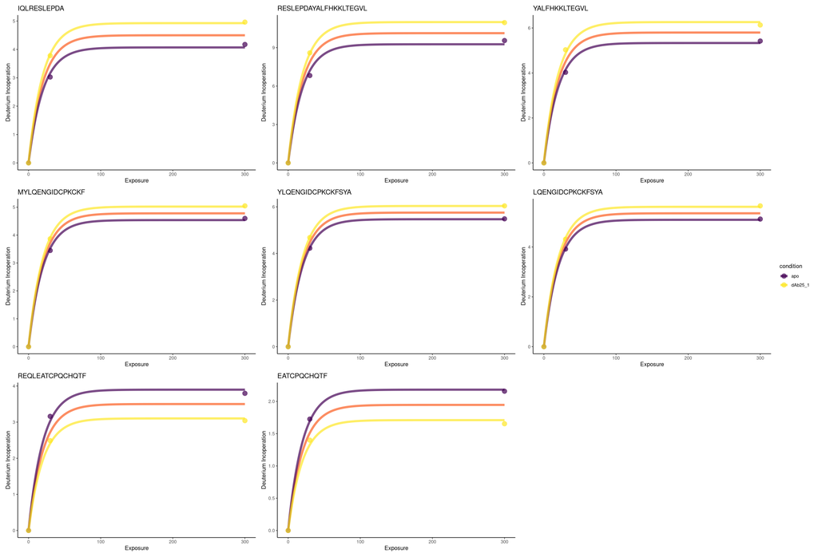

```r
(res_all@statmodels[[36]]@vis +
res_all@statmodels[[42]]@vis  +
res_all@statmodels[[43]]@vis  +
res_all@statmodels[[65]]@vis  +
res_all@statmodels[[68]]@vis  +
res_all@statmodels[[70]]@vis  +
res_all@statmodels[[52]]@vis  +
res_all@statmodels[[53]]@vis ) + plot_layout(guides = 'collect')
```

We can make a Manhattan plot to better specially visualise what’s happening.

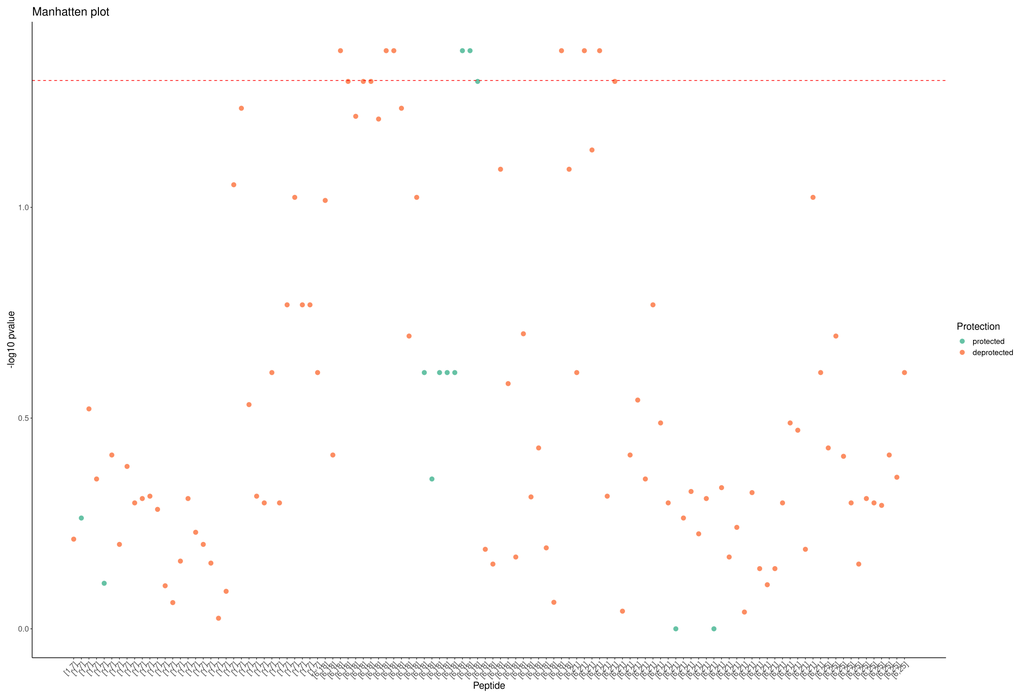

```r
#We need to provide an indication of "difference" so we can examine deprotected
# or prected regions
diffdata <- assay(newqDF)[,6] - assay(newqDF)[,3]


sigplots <- manhattanplot(params = funresdAb25_1,
                          sequences = HOIP$Sequence,
                          region = HOIP[, c("Start", "End")],
                          difference = diffdata,
                          nrow = 1)
sigplots[[1]] + plot_layout(guides = 'collect')
```

We can visualise this in a peptide plot which helps us understand the nature of the overlap

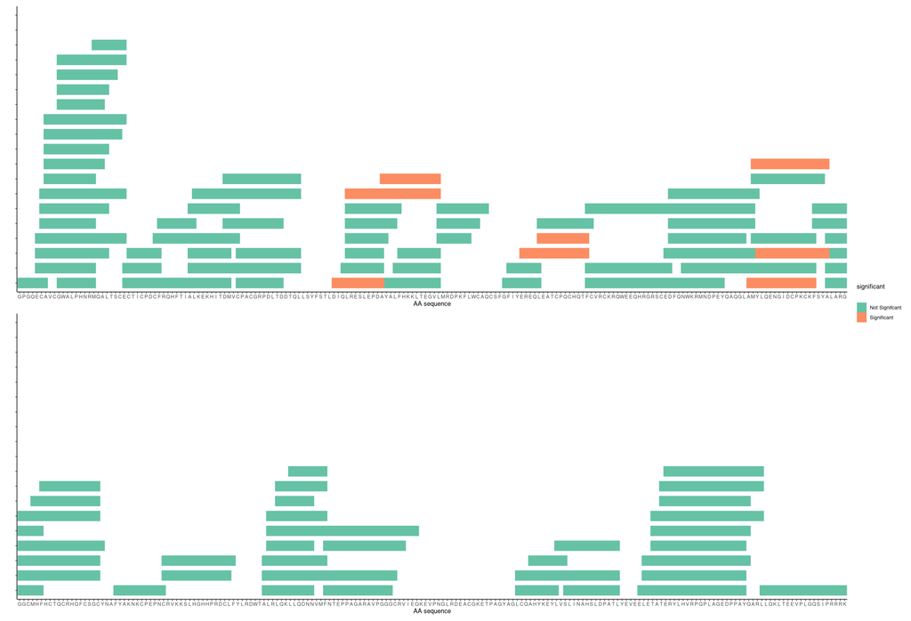

```r
fpath <- system.file("extdata", "HOIP.txt", package = "hdxstats", mustWork = TRUE)
HOIPfasta <- readAAStringSet(filepath = fpath, "fasta")

scores <- funresdAb25_1@results$ebayes.fdr

out <- plotEpitopeMap(AAString = HOIPfasta[[1]],
                      peptideSeqs = unique(HOIP$Sequence),
                      numlines = 2,
                      maxmismatch = 1,
                      by = 1,
                      scores = 1 * (-log10(scores[unique(HOIP$Sequence)])  > -log10(0.05)) + 0.0001,
                      name = "significant")
out[[1]]/(out[[2]]) + plot_layout(guides = 'collect') & theme(legend.position = "right")
```

We can further visualise this a barcode of particular residues, here we use residue level averaging to obtain results at the residue level.

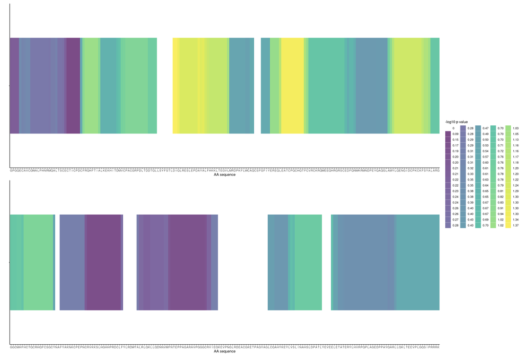

```r
scores <- funresdAb25_1@results$ebayes.fdr
out2 <- plotEpitopeMapResidue(AAString = HOIPfasta[[1]],
                              peptideSeqs = unique(HOIP$Sequence),
                              numlines = 2,
                              maxmismatch = 1,
                              by = 5,
                              scores = scores[unique(HOIP$Sequence)],
                              name = "-log10 p value")
out2[[1]]/out2[[2]]  + plot_layout(guides = 'collect') & theme(legend.position = "right")
```

We can also plot multiple residue maps on the same plot so that we can compare different antibodies.

```r
scores <- funresdAb25_1@results$ebayes.fdr
avMap25_1 <- ComputeAverageMap(AAString = HOIPfasta[[1]],
                               peptideSeqs = unique(HOIP$Sequence),
                               numlines = 2, maxmismatch = 1,
                               by = 10, scores = scores[unique(HOIP$Sequence)],
                               name = "-log10 p value")

## generate results from other dAB
cn <- new.colnames[c(1:3,19:21)]
HOIP_wide_nrm <- data.frame(HOIP_wide)
HOIP_wide_nrm[,c(2:4)] <- HOIP_wide_nrm[,c(2:4)] - HOIP_wide_nrm[,c(2)]
HOIP_wide_nrm[,c(20:22)] <- HOIP_wide_nrm[,c(20:22)] - HOIP_wide_nrm[,c(20)]

newqDF2 <- parseDeutData(object = DataFrame(HOIP_wide_nrm),
                        design = cn,
                        quantcol = c(2:4,20:22),
                        rownames = HOIP_wide$Sequence)

res_all2 <- fitUptakeKinetics(object = newqDF2[,1:6],
                             feature = rownames(newqDF2[,1:6])[[1]],
                             start = list(a = NULL),
                             formula = value ~ a * (1 - exp(-0.07*(timepoint))))
```

[output not shown]

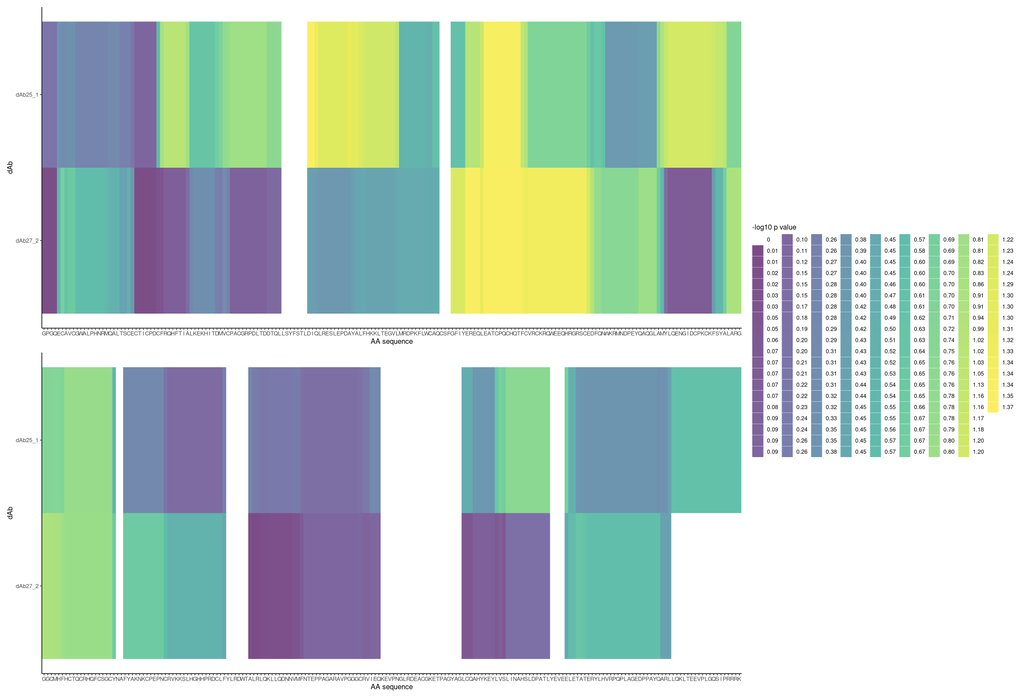

```r
funresdAb27_2 <- processFunctional(object = newqDF[,1:6],
                                   params = res_all2)

scores <- funresdAb27_2@results$ebayes.fdr
# compute average map
avMap27_2  <- ComputeAverageMap(AAString = HOIPfasta[[1]],
                                peptideSeqs = unique(HOIP$Sequence),
                                numlines = 2,
                                maxmismatch = 1,
                                by = 10,
                                scores = scores[unique(HOIP$Sequence)],
                                name = "-log10 p value")

# set rownames
rownames(avMap25_1) <- "dAb25_1"
rownames(avMap27_2) <- "dAb27_2"

# store in a list
avMap <- list(avMap27_2 = avMap27_2,
              avMap25_1 = avMap25_1)

#plotting
out3 <- plotAverageMaps(avMap, by = 20)
out3[[1]]/out3[[2]]  + plot_layout(guides = 'collect') & theme(legend.position = "right")
```